# Grade 6 Maths

Prem

Monday, April 11, 2016

https://www.khanacademy.org/math/in-sixth-grade-math https://www.khanacademy.org/profile/peterwcollingridge/

http://betterexplained.com/articles/learning-how-to-count-avoiding-the-fencepost-problem/

# Chapter 1: Knowing our numbers

## Comparing numbers

- **Writing Numbers in Expanded form**
  - write $14,987$ in expanded
  - $1 * 10,000 = 10,000$
  - $4 * 1,000 = 4,000$
  - $9 * 100 = 900$
  - $8 * 10 = 80$
  - $7 * 1 = 7$
  - $10000+4000+900+80+7 = 14,987$

## Large Numbers in Practice

- In this topic we’ll look at the basics of **number approximation**, when we round numbers to be less exact
- This would happen when you don’t trust your measurements or want to simplify things, in other words when you want to **roughly** know the number

### Rounding to nearest 10

- What is the nearest multiple of 10 for a given number?
- Look at value in **ones column**, one place to the right of the **tens**, and decide which multiple of ten is closest, then Round up or Round down
- multiples of ten = $10,20,30,40,50,60,70,80,90$
- `value:nearest multiple of ten` = 36:40, 34:30, 65:70, 92:90, 12:10

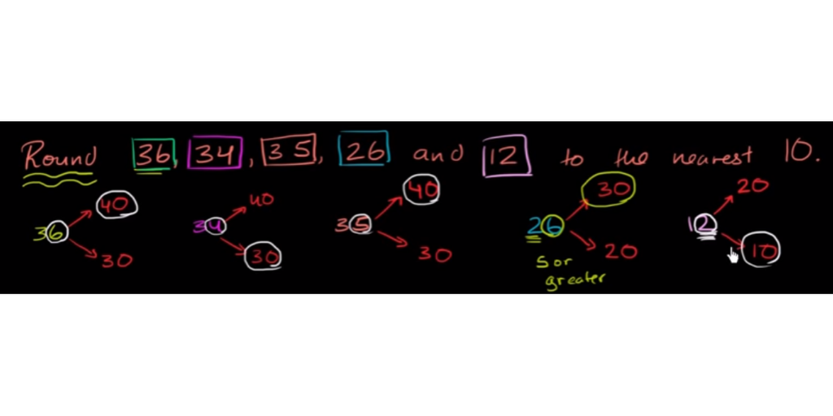

- *note*: Rule of Rounding 5: When rounding number 5, which is 5 away from one multiple and 5 away from the other, the rule is to round up
  - This is just a rule

### Rounding to nearest 100

- Look at value one place to the right of the **hundreds** column, in the **tens** column and decide which multiple of hundred is closest.
- `value:nearest multiple of ten/hundred` = $154:150/200,\\ 4,674:4,670/4,700,\\ 9,995:10,000/10,000,\\ 8,346:8,350/8300$

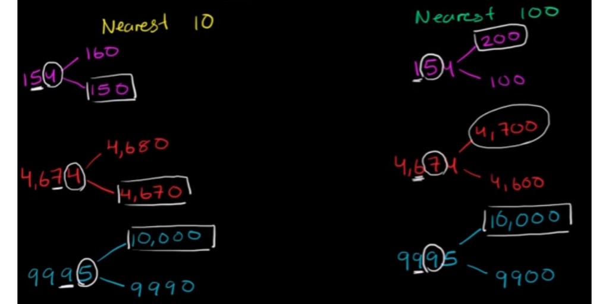

### 2 step estimation problem

- The Pokemon day-care centre has 128 orphaned Pokemon. They’ve just been given another 54. The daycare wants to share these Pokemon amongst the 43 people who have signed up to take a Pokemon. **Roughly speaking** how many Pokemon will each trainer get?
  1. Round 128 and 54 to the nearest ten
     - 120 + 50 = 170 Pokemon
  2. Round the amount of trainers to the nearest ten
     - 40
  3. Divide the amount of Pokemon by amount of trainers
     - Let `P` be amount of Pokemon
     - 170 / 40 = P
     - P x 40 = 170. Solve for P
     - List Multiples of 40: 40, 80, 120, **160**, 200.
     - 170/40 = 4 Pokemon. Each Trainer will receive roughly 4 Pokemon.

### Multiplication estimation example

- A ticket agent sells 42 tickets. Tickets cost £28 each. Use rounding to estimate the total amount of money from sales
  1. Round number of tickets and cost of tickets to nearest ten
     - 40 tickets
     - £30 each
  2. Multiply together
     - 40*30 = 4*3 with two zeroes added on the end (12 -> 1,200)
     - Roughly we will have £1,200 from sales

## Using Brackets

### Constructing Numerical Expressions with Parathesis

- Mike and Amon are having a beyblade battle. Amon has 3 Beyblades and wins 1 more. He then battles Mike for all or nothing, doubling his amount of Beyblades. **Write an expression to model this situation without performing any operations**
  - $2(3+1)$

# Chapter 2: Whole Numbers

## Properties of Whole Numbers

### Commutative Law of addition

- **commutative law** = order doesn’t matter if you’re adding a bunch of things. i.e. you can add numbers in any order and the result will always be the same
  - $10+20+4=34$
  - $4+10+20=34$

### Commutative law of multiplcations

- **commutative law** = numbers can be multiplied in any order and the result will always be the same

### Associative law of addition

- **associative law of addition** = It doesn’t matter which numbers are added first in paranthesis, the result will always be the same
  - i.e. it doesn’t matter if you associate the 20 with the 1, or the 1 with the 4.
  - (20+1)+4 = 25
  - (1+4)+20 = 25

### Associative law of multiplication

- **Associative law of multiplication** = It doesn’t matter which numbers are added first in brackets, the result will always be the same

### Distributive property over addition

- **distributive law of multiplication over addition** = distributive the number you are multiplying by to each number in the brackets
  - 4(8+3). Distribute the 4 to each number
  - (4*8)+(4*3)
  - 32+12 = 44
- **Why use distributive law instead of just BODMAS (adding numbers in brackets first)?**
  - Using the distributive law helps you in algebra, when you will have variables
  - **example 1**:
  - 4(8+x)=44. Solve for `x`
  - (4*8) + (4*x) = 44
  - 32 + 4x = 44
  - 4x = 12
  - x = 3
  - **example 2**:
  - Each month you pay the following bills: Water:$30, Electricity:$150, Cable:$70. How much do you pay in a year and how much is each item?
  - 12(30w,150e,70c)
  - 360w + 1800e + 840c = $3000.
  - We could of added the bills together, then multiplied [12(250) = 3000], but you would of lost crucial information about how much **each** bill costs
  - **Related Branches**: Factoring, Polynomials, Algebra. Knowing the distributive law will be useful when you reach those branches

### Distrbutive property over substraction

- **distributive law of multiplication over substraction** = distributive the number you are multiplying by to each number in the brackets
  - $5(9-4)$
  - $5*9-5*4$
  - $45-20$
  - $25$

### Summary

- **Commumative Law** = a+b+c = b+c+a
- **Associative law** = a+(b+c) = b+(a+c)
- **Distributive property** = a+b(c+d) = a+bc+bd

# Chapter 3: Playing with Numbers

- In this chapter we will learn about factors and multiples and about the divisibility rules for 2, 3, 4, 5, 6, 8, 9 and 10

## Factors and Multiples

- In this topic we will see that a factor of a number is an exact divisor of that number, and a multiple is a result of the multiplication of that number

### Finding Factors of a Number

- In this tutorial we’ll begin to look at the numbers that “make up” the number
- **Use**: This will be useful throughout maths, whether we are adding up fractions, exploring mystical numbers patterns or breaking computer codes, factoring numbers are key!
- **factor** = the factory that *makes* a whole number from parts
  - *note*: factor comes from latin and makes do/make. The factor makes something happen. In math, a factor makes a result happen, it produces the result
  - i.e. 2 and 6 make 12 happen / 2 and 6 produce a result of 12 (2*6= 12)
- **Finding Factors**
  1. Write the smallest and largest factor
  2. Work up the number line(1:10), filling in the gaps between the smallest and largest factor
  3. Keep going until the gaps are filled
- **Recognizing Divisibility**: is x divisible by…
  - Number 1. All Whole Numbers are divisble by 1
  - Number 2. The number is even (i.e, the last digit is 2, 4, 6, 8, 0)
  - Number 3. The digits add up to a multiple of 3.
    - If you’re unsure if the sum is multiple of 3, you can check the sum it self by adding the digits together.
    - I.e. Is 386, 802 divisble by 3? 3+8+6+8+0+2=27. Not sure if 27 is multiple of 3? 2+7=9. Yes, 9 (therefore 27) is multiple of 3.
  - Number 4. The last two digits are a multiple of 4
  - Number 5. The last digit is zero or 5
  - Number 6. Divisible by both 2 and 3
  - Number 7.
  - Number 8. The last three digits are divisble by 8
  - Number 9. The digits add up to a multiple of 9
  - Number 10. The last digit is zero
- **Find All Factors of 120**
- $120 = 1 * 120$
- $120 = 2 * 60$. Is x divisible by 2? Check if one’s place is even.
- $120 = 3 * 40$. Is x divisible by 3? Add up its digits and see if sum is divisible by three. I.e. 1+2+0 = 3. Yes, 120 is divisible by 3.
- $120 = 4 * 30$ Is x divisible by 4? You ignore everything beyond hundreth’s place and look at last two digits.i.e., is 20 divisible by 4, so 120 is also divisible by 4.
- $120 = 5 * 24$ Is x divisible by 5? If last digit is 0 or 5, then yes
- $120 = 6 * 20$. Is x divisible by 6? If divisible by 2 and 3, yes
- $120 = 8 * 15$ Is x divisible by 8? If last 3 digits divisble by 8, yes
- $120 = 10 * 12$ Is x divisble by 10? If last digit is 0, then yes
- Factors of 120 are: 1 2 3 4 5 6 8 10 12 15 20 24 30 40 60 120

```
FUN <- function(x) {
    # Convert number to integer to speed up function
    x <- as.integer(x)
    # Find all numbers to divide by (1:x)
    div <- seq_len(abs(x))
    # Only return numbers where division results in no remainder
    # 0L, the `L` notation ensures number is stored a a integer
    # not a double
    factors <- div[x %% div == 0L]
    # Make a list with negative and positive factors
    factors <- list(neg = -factors, pos = factors)
    return(factors)
}
```

### Find Multiples Of A Number

- To find a multiple the best way is just simply list the multiples by doing your times table
- factor x factor = multiple

## Prime and Composite Numbers

- In this topic we will see that composite numbers have more than one factor and prime numbers have just two: 1 and the number itself
- Prime numbers have been studied by mathematicians and mystics for eons. By studying them you will unfold more fascinating views of the universe
- **use**: Prime numbers are used in cryptography and studying nature, it’s what decides how many petals a flower has and what stops theives from entering your online bank account

### Prime Numbers

- Prime numbers are the building blocks of numbers, that can not be broken down into products of smaller numbers
- **prime number** = A natural number (1,2,3…) divisible by **exactly two** natural numbers, 1 and itself
  - 1 = not prime. Only divisible by one number, not exactly two
  - 2 = prime number. Is divisble by 1 and it self
    - 2 is the only even number that is prime
- **Identifying Prime Numbers**
  - Divide number by all the numbers between 1 and it self. If the number is only divisible by 1 and it self then it is prime

[output not shown]

## Test for Divisbillity of numbers

### The why of the three divisibillity

- Take Number, such as 498
- Re-write number as something that is “1 + something divisble by 3”"
  - 498 -> 4(1+99) + 9(1+9) + 8
  - Instead of writing 4(100)…the trick is write 4(1+something-divisible-by-3) instead of 100
- Distribute the four and re-arrange terms
  - 4+(4*99)+9+(9*9)+8.
  - 4(99) + 9(9) + 4 + 9 + 8. # Re-arrange the terms
- Check if terms are divisible by 3
  - 4(99), divisible by 3 **because anything multipled by something divisible by three** is divisible by three!
  - 9(99), divisible by 3, because anything multiplied by something divisible ny three is divisble by three!
  - 4(99) + 9(99), If you add**two things which are divisible by three added, the whole thing is still going to by divisble by three**
  - 4 + 9 + 8 = 21. 2+1. **What are we left with? Our original digits!** Just need to make sure original digits are divisble by three
  - In other words, 498 is divisble by 3 if 4 + 9 + 8 is divisible by 3!

### Why can’t I add all the digits to see if its divisble by four?

read comments

Say you have the number 19. That is 1 ten and 9 units. If you increase the value by one, you would have 10 in the units place. Since you can’t have that you increase the tens place to 1 and decrease the units place by 10 to get 2 ten and 0 units. The sum of the digits therefore decreases from 11 (1 ten and 10 units) to 2 (2 ten and 0 units), which is a decrease of 9.

https://www.khanacademy.org/math/in-sixth-grade-math/playing-numbers/test-divisibility-numbers/v/the-why-of-the-3-divisibility-rule

### The Why of the 9 divisbillity rule?

- is 2943 divisble by 9?
1. Break the number up by place value
   - 2(1000) + 9(100) + 4(10) + 3
2. Re-write as “1 + something divisble by 9”
   - 2(1+999)+9(1+99)+4(1+9)+3
3. Distribute
   - 2+(2*999)+9+(9*99)+4+(9*4)+3
4. Re-arrange the terms *(2*999)+(9*99)+(9*4)+2+9+4+3
5. Check divisibillity of all parts
   - (2*999)+(9*99)+(9*4) = yes. Anything times something divisible by 9 is divisble by 9
   - 2+9+4+3 = yes. Second part needs to be divisble by 9 in order for the whole number (2943) to be divisible by 9.
   - In other words, 2943 is divisble by 9 if 2+9+4+3 is divisible by 9! ### The why of the 4 divisibillity rule
- is 419108 disivible by 4?
- A number is disible by 4 if the last two digits are divisble by 4
1. We-can re-write the number as a multiple of 100 plus the last two digits
   - 419108 = 4191 + 08 Because 419100 is a multiple of 100, it is also a multiple of 4
2. So long as the last two-digits are divisble by four then the original number must be divisble b four!

## Common Divisibillity

- Concepts = prime factors, division
- All numbers divisible by A and B are also divisible by…
- **example** All numbers divisble by 21 and 20 are also divisble by…
  - 333?
  - 30?
  - 172?
  - 147?
  - 222?
  1. Find Prime Factors for 21 and 20
  - 21 = 7 * 3. 20 = 5*2*2
  - Any number divisble by both 21 and 20 must have 2*2*3*5*7 as part of its prime factorization
  2. Check if the prime factors of the options match
  - The prime factors of 30 is 2*3*5
  - Since 2*3*5 is a part of 2*2*3*5*7, all numbers divisble by 21 and 20 must be divisible by 30.

## Prime Factorization

- You know what prime numbers are and how to identify them, in this tutorial we will look at how all positive numbers can be broken down into products of prime numbers (In some ways, prime numbers as the atoms of the number world that can be multiplied to create any number!). Besides being a fascinating idea, it’s extremely useful! Prime factorization can be used to decrypt encrypted information.
- Concepts = division, prime factors.

### Finding the prime factors

Find the prime factorisation of 75. Write your answer using exponential notation.

1. Work through lists of primes, finding the smallest prime number that will go into 75.
- **note**: this is where learning about divisibillity rules comes in handy
  - list of primes = 2,3,5,7,11…
  - Is 75 divisible by 2? No. Ones place is not even.
  - is 75 divisible by 3? Yes. 5+7=12, which is divisble by 3.
  - 75 = 3 * 25
  - Find the factors of 25.
  - is 25 divisble by 2? No. If it’s not divisble by 75, then won’t be by 25.
  - is 25 divisble by 3? No. 2+5 = 3.
  - is 25 divisble by 5? Yes.
  - 25 = 5 * 5
  - We’re done, we’re left with only primes!
  - 75 = 3 * 5 * 5
2. Re-write using exponential notation
   - If we have repeated primes we can write those as exponents
   - 5*5 is the same thing as 5^2
   - 75 = 3 * 5^2

## Lowest Common Multiple

- Life is good but it can be better. Just imagine being able to find the smallest number that is a multiple of two other numbers! Other than making your life more fufilling, it will allow you to do incredible things like adding fractions
- `concepts` = Prime Factors, Fractions, Addition
- `use` =
  - Adding fractions
  - Wastage. For example, if buns come in packs of ten and burgers in packs of 8. If you don’t want to waste any you will need to buy the LCM of buns and burgers. e.g. LCM(10,8). This also occurs in manufacturing, where one company will only give you parts in packages of X and another will only give you parts in packes of Y. If you need one of each to make your product you will need to find the LCM(X,Y) to avoid waste parts.
  - Finding best deals.
- **Method 1: Prime Factorization**
  - What is the LCM of A and B?
  - Take Prime Factorization of A and B and construct smallest number whose ingredients is all the factors of both A and B, which will be the LCM
  - What is the LCM of 12 and 18?
  1. Find prime Factors of 12 and 18 using factorization trees
     - 12 = 2*2*3
     - 18 = 2*3*3
  2. Multiply of the factors that appear in both numbers and construct a new number
  - The LCM has a super-set containing all of these factors or all of these factors in it as many times as we have it in any one of these (A or B)
  - in order to be divisible by 12 you need to have two 2’s and atleast one 3. But to be disivisible by 18 you need another 3! 2*3*3*2 is divisible by both 12 and 18.
  - LCM(18,12) = 2*3*3*2 = 36
- **Method 2: Brute Force**
  - Go through times table for both numbers until you find LCM
- Method 1 (Prime Factorization) is better as firstly, you deconstruct the number (so it’s fun!) and secondly, things will get hairer with larger numbers so it’s easier, quicker and cleaner to have a systematic method

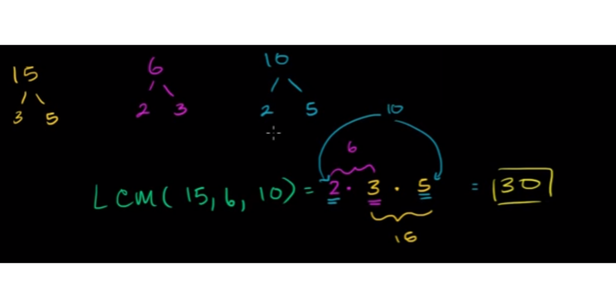

- **note**: if two numbers do not share any common factors, i.e. they are both primes, then their LCM is a product of the two
  - What is the LCM of 11 and 13?
  - 11 and 13 do not share any common factors, so LCM is product of both
  - LCM = 11 * 13 = 143 ## Greatest Common Factor
- You know how to find factors of a number. What about factors that are common to two numbers? Even better, imagine the largest factors that are common to two numbers.
- **note**: It’s better to just use method 2.
- What is the GCF of A and B?
  - Finding the GCF/GCD(greatest common *divisor*) is finding the largest number that divides into both numbers
- **method 1: Common Factors**:
  - List all factors for each number, and find the greatest common factor
  - What is the GCF of 10 and 7?
    - 10 = 1,2,5,10
    - 7 = 1,7
    - GFC(10,7) = 1
  - **note**: two numbers with only 1 as their GCF is known as **relatively prime**
- **Method 2: Common Prime Factors**:
  - List all prime factors for each number, and find the largest set of common prime factors
  - The greatest common factor will be a product of the set
  - What is the GCF of 30 and 15?
    - 30 = 2,3,5
    - 21 = 7,3
    - GFC(30,31) = 3
  - What is the GCF of 105 and 30?
    1. Factor each number completely as a product of its primes
       - 105 = 3, 5, 7
       - 30 = 2,3,5
    2. Find the common prime factors
       - Largest Set of Common Prime Factors = 3,5
    - GCF(105,30) = 3*5 = 15
    - 15 is the largest number divisible into both numbers
  - **note**: If numbers do not share any prime factors, then the GCF is 1 as this factor is common to all numbers
  - What is the GCF of 60 and 60?
    1. Factor each number completely as a product of its primes
       - 160 = 2,2,3,5
       - 60 = 2,2,3,5
    - Both numbers share all of their factors, so GCF = 2*2*3*5 = 60
  - **note**: In general, the greatest common factor of any number and its self is that number

## GCF and LCM word problems

- **Example 1**: There are 32 forwards and 80 guards in Leo’s basketball league. Leo must include all players on a team and wants each team to have the same number of forwards and the same number of guards. If Leo creates the greatest number of teams possible, how many guards will be on each team?
  - In order to find out how many teams Leo can create, we need a number that is a factor of 32 and 80, so that the 32 forwards and 80 guards can be divided up evenly.
  - So, if there were 4 teams, there would be 32/4= 8 forwards and 80/4= 20 gaurds on each team. This creates equal teams (the same number of players on each team) but it isn’t the **greatest number of teams possible!**
  - To find the greatest number of teams, we need to find the GCF of 32 and 80.
    - gfc(32,80) = 16
  - The greatest number of teams Leo can make is 16.
  - Each team would have 32 / 16 = 2 forwards and 80/16 = 5 gaurds
- **example 2**: Professor Oak has 32 Pokeballs and 8 Rare Candies. He wants to give all of these in identical gift bags to new trainers. What is the most amount of gift bags he can make?
  - To find the greatest number of gift bags we need to find the Greatest Common Factor of 32 and 8
  - In other words, find the GCF(32,8) = 8.
  - There will be 8 identical packages, which contain 32/8 = 4 Pokeballs and 8/8 = 1 Rare Candy.
- **example 3**: Ged milks the goats every 8 days and goes to market every 6. Today he did both on the same day. How many days until he milks and the goat and goes to the market on the same day?
  - Let’s look at Ged’s diary, by going up the times table for each number.
    - 8 = 8,16,24
    - 6 = 6,12,16,24
  - As we keep going we find that the multiples meet on the 24th day.
    - Mathematically we say that 24 is the Least Common Multiple of 8 and 16. LCM(8,16) = 24
  - It will be 24 days until ged milks the goats and goes to market on the same day
  - **note**: although I’ve listed the multiples of each number, which is the brute force method, for clarity, it is easier to simply work out the LCM via the Prime Factorization Method.

# Uses

## Factors

### GCF

- Creating Identical Packages with two items(A and B)
  - Find GCF, divide each item by GCF
  - GCF = the greatest number of packages that can be made
  - item / GCF = amount of items in each package
    - A / GCF = number of item A in each package
    - B / GCF = number of item B in each package
- Splitting items A and B into identical rows
  - Find GCF, divide each item by GCF
  - GCF = the greatest number of rows that can be planted
  - item / GCF = amount of items in each row
    - A / GCF = number of item A in each package
    - B / GCF = number of item B in each package
- Simplify fractions
  - Find GCF of num/dom, divide each by GCF

### LCM

- **LCM** is great for finding where two events will occur together, by finding where the multiples of each number first meet
- Preventing Wastage. item A and B is needed to build a product/make a hotdog. You can only buy item A in packs of X and item B in packs of Y.
  - Find LCM, divide LCM by each pack
  - LCM(X,Y) = smallest total number of item A/B you can buy without wasting.
    - I.e. the amount of items you need of A and B each to not have any left-overs.
  - LCM / packs = amount of packs you need to buy of each item
    - LCM / X = amount of packs you need to buy of item A
    - LCM / Y = amount of packs you need to buy of item B
- Finding over-lapping events
- Finding minimum over-lapping scores.
  - Pikachu gains 8 points with every match. Squirtle gains 9 points. At the end of the day, each pokemon has the same amount of points.
  - Find LCM.
  - LCM = Least number of total points that person A and B could of each achieved
  - Pikachu gains 8 points with every match. Squirtle gains 9 points. At the end of the day, each pokemon has the same amount of points. What is the least amount of matches Pikachu could of had?
  - Find LCM, divide LCM by points per event for each person
  - LCM = Least number of total points that person A and B could of each achieved
  - LCM / points per event = amount of events that each person did in order to reach the same score
- **compare unlike fractions**
  - Find the lowest common denominator of two unlike fractions, so you can compare them

# Chapter 4: Basic Geometrical Ideas

## Introduction

- **Euclid Father Of Geometery** = Euclid, born 2,500 years ago in Alexandira was the first person to prove something beyond doubt. Not simply have a good feeling but prove that something is wholly correct for the whole universe.

While he wasn’t the first to study geometery, many peoples would of before him simply by looking at the shapes around us in nature and considering what shapes will help us build structures, like pots or even Pyramids. However in his book he essentially under-pinned modern maths which is begining with an basic assumption, known as a theorem, and then going to prove it, known as a proof. Thus, Euclid’s legacy lies in turning theorems, stuff you feel pretty sure about, into proofs, stuff you know beyond a shadow of a doubt!

## Terms & Labels in Geometery

- **geometery** = *geo* is earth and *metery* is measure, so it is the measurement of earth/nature
- In geometery we have a few attributes(ideas/things) that apply to all geometric terms
  - dimension = the amount of options to travel in
  - label = to identify terms we use labels rather than colours, sounds or pictures.
- **point** = a single dot which is fixed in one place.
  - dimension = 0. A point can’t travel in any direction or it will cease to be that point, so it has zero dimensions
  - label = $A$. The label for a point is a single letter within the Alphabet, one point could be A, another B
- **line segment** = two dots connected by a line / a part of a line bounded by two end points. Line *segments* have an end-point so are **finite* in length
  - dimensions = 1. A line segment is able to move back and forth, i.e. left and right
    - note: the geometric line has no width and only length, although in reality strings and sticks do have a width.
  - label = $\overline{AB}$, if you have two points (A&B) connected by a line
  - **end point** = the points at the end of a line segment (A&B)
  - Line Segments are the most common things in geometery, as you will study the sides of shapes and distance between point. Anything with a finite length is a line segment
- **ray** = a line segment which starts at one point and extends forever in one direction
  - dimensions = 1. Back and forth long the line
  - label = $\overrightarrow{AB}$: a line that extends past point B. *note* that the order of points matters, e.g. $\overrightarrow{BA}$ means a line that extends past point A.
  - vertex = the starting point of a ray
- **line** = a line segment that extends forever in both directions. Lines have no start/end point.
  - dimensions = 1
  - label = $\overleftrightarrow{AB}$
  - **midpoint** = a point that is exactly half-way between two points.
  - **collinear** = points that sit on the same line, pretty much all points and midpoints along a given segment.
- **planar/planes** = a infinite 2D space. Extends in all directions forever
  - dimension = 2. It can travel along 2 ways, up/down and left/right.
  - **planar segment** = piece of a paper/computer monitor. It is 2D, but finite

### Measuring Segments

- **congruent** = two line sigments with the same length

## Parallel and perpendicular lines

### Identifying parallel and perpendicular lines

- **identifying parallel lines** = if two suspected parallel lines intersect a third line at the same angle, then they are parallel

## Angles

Angles are formed where corners are made.

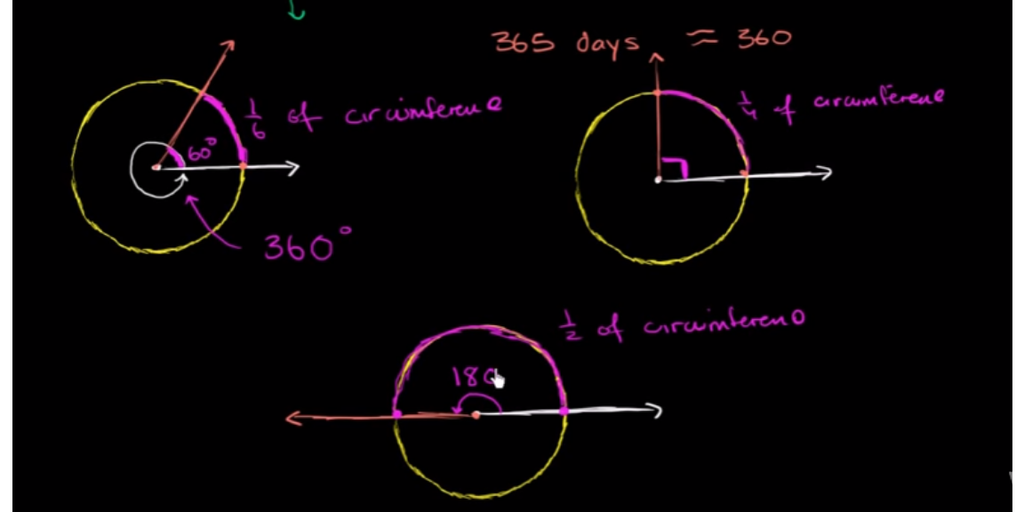

## Circles

### Circles Glossary

- Formal definition of a circle. Tangent and secant lines. Diameters and radii. major and minor arcs
- **circle** = set of all points a fixed distance from A
  - Draw a point named `A`. `A` is the centre point, draw points in every possible posistion that are 2cms from `A`. You now have a circle
  - **centre point** = the point in the *middle* of the circle that is a equal distance from every point *on* the circle itself
    - Point `A` in the diagram below
- **radius** = line between centre-point and circumference (any point on the circle itself)
  - $\overline{AB} = 2cm$
- **tanget** = line that only interescts (touches) one point *on* the circle
  - $\overleftrightarrow{CM}$
  - Line `L` is tanget to the circle centered at `A`
  - Important to state circle’s centre-point or else it could be refer to any circle!
- **secent** = line interesects (touches) two points on the circle
  - $\overleftrightarrow{DF}$
- **cord** = line segment between two points, a finite secent
  - $\overline{DF}$
- **diameter** = cord that passes through circle’s centre-point
  - diameter is composed of 2 radii
  - $\overline{CG}$
  - `CG` = `CA` + `AG`
- **arc** = line between two points *along* the circle
  - **minor arc** = quickest path between two points
    - $\frown {BG}$
  - **major arc** = longer path between two points
    - $\frown {BFG} = \frown {BDG}$

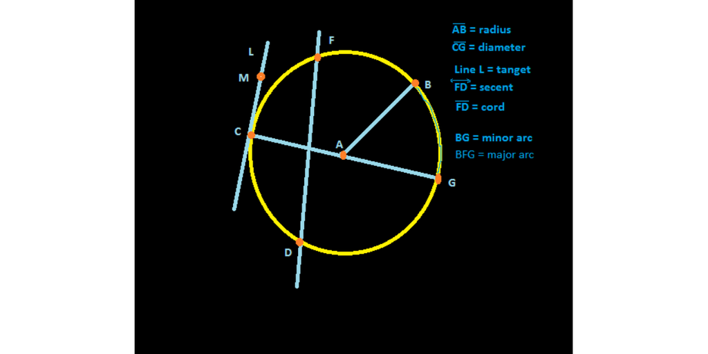

# Chapter 5: Unerstanding elementary shapes

- corners, edges, planes, open curves and closed curves are different shapes we seen around us. Understanding these shapes can help us solve a wide variety of real life problems

## Angles: acute, obtuse and reflex

- **acute** = angle less than 90 degrees. Rays are close to each other
- **right-angle** = 90 degrees. Rays are perpendicular to each other
- **obtuse** = more than 90 degrees.

## Measuring Angles

- To review, a circle is split into 360 equal parts. Each part is called a degree, which is one way we measure angles.

### Decomposing Angles

- To find out the measure of an angle, you can add or substract other angles

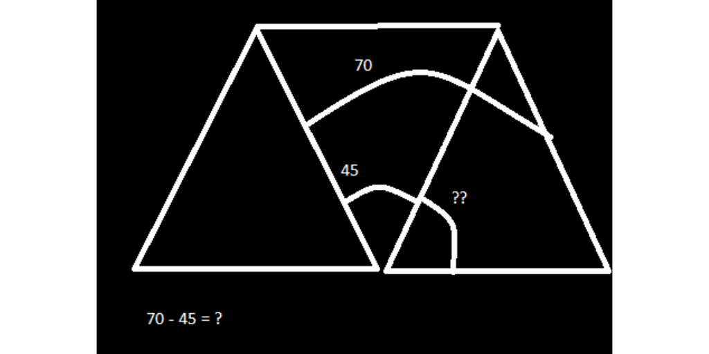

### Classifying Triangles

- There are **two methods** to classify triangles based on either the number of **equal sides** or the **angle measure**
- **number of equal sides**
  - **scalene** = triangle with no equal sides
    - no sides are congruent
  - **isosceles** = triangle with at least two equal sides
    - two sides are congruent
  - **equilateral** = triangle with all equal sides
    - all sides are congruent
    - Yes, an equilateral is does also count as a isosceles
- **angle measure**
  - **acute** = all angles under 90 degrees
  - **right angle** = one angle is 90 degrees
  - **obtuse** = one angle is over 90 degrees
  - *note*: all angles add up to 180
- When you don’t know the lengths of the sides the angles come in handy.
  - **scalene** = no angles are equal
  - **isoceles** = 2 angles are equal
  - **equilateral = all angles are equal (60 degrees)

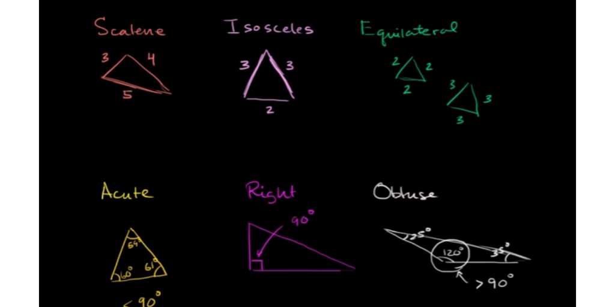

## Quadrilaterals

### Quadrilateral Glossary

- **quadrilateral** = any shape with four shapes
- **concave** = has interior angle larger than 180 degrees. This means none of the sides can be parallel to each other
  - **note**: if angles were equal to 180 degrees, rather than more (concave) or less (convex) then it would be straight lines creating a triangle
- **convex** = all of the interior angle less than 180 degrees.
  - **trapezoid** = exactly one pair of parallel sides
  - **parallelogram** = two pairs of parallel sides
    - **rectangle** = all 4 angles are a right angles
    - **rhombus** = all 4 sides are equal
    - **square** = rhombus + rectangle
- **note**: sum of any quadrilateral is 360 degrees

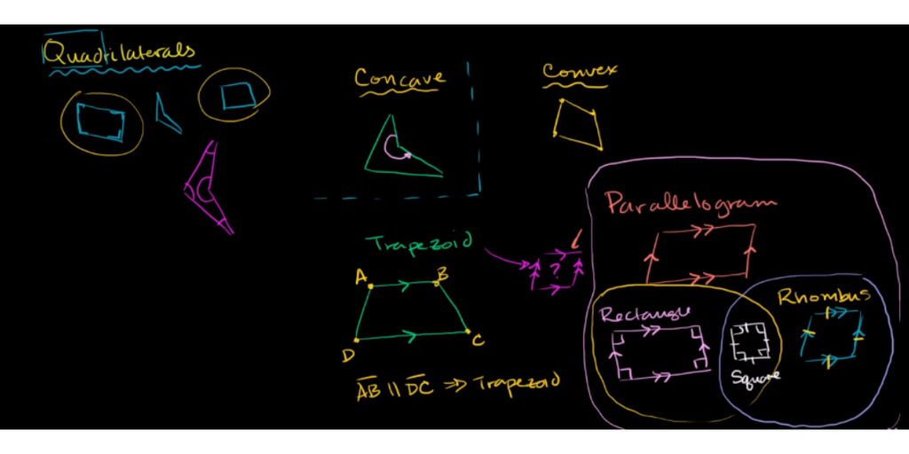

# Chapter 6: Integers

## Integers

- If you put the whole numbers and the negative numbers together you get a new collection of numbers known as integers.

### Negative Integers

- **negative number** = a number that is less than zero
- There are two ways to conceptulize negative numbers. One is a lack of something, such as a lack of temperature (freezing) or a lack of money (debt), the other is distance in relation to zero.
- **distance from zero** = there are two parts to a number. It’s absolute value and it’s symbol.
  - The **absolute value** tells how far the number is from zero
  - The **symbol** tells you in which direction. `negative` = left of zero, `positive` = right of zero.
- **lack of something** = negative numbers help us model real life situations, such as having debt. If you owe someone $2 and have a balance of $1, then you have a balance of -$1. While -$1 doesn’t actually exist, it does help us keep track of of things, such as owing money or loosing health in a game.
- *note*: there is a difference between the **operation** of subtraction and the **object**(a negative number), even though both use the same sign. You should therefore say *subtract negative 3* and not *minus minus 3* to keep things clear.
- **[history](https://nrich.maths.org/5961)**:
  - rules for dealing with negative numbers first appeared in 7th century India, written down by Brahmagupta.
  - However, references to negative numbers existed during 200 BCE in China, where positive numbers were items sold (money in) and negative were items brought (money out)
  - Greeks did not address negative numbers, as they dealt with geometery. Lengths, areas and volumes of shapes all had to be positive. Futhermore, their ideas were based on magnitudes. Magnitudes were represented by a line or an area, not by a number.
  - Negative numbers appeared in Europe by the 15th century, after islamic and byzantine sources were translated

  ```
  A debt minus zero is a debt.
      a negative substract zero is a negative
  A fortune minus zero is a fortune.
      a positive substract zero is a positive
  Zero minus zero is a zero.
      zero subtract zero is zero
  A debt subtracted from zero is a fortune.
      a zero subtract a negative is a positive
  A fortune subtracted from zero is a debt. 0-(pos) = neg
      a zero subtract a positive is a negative. 0-(neg) = pos
  The product of zero multiplied by a debt or fortune is zero.
      zero multiplied by a negative or positive is zero
  The product of zero multiplied by zero is zero.
      zero times zero is zero
  The product or quotient of two fortunes is one fortune.
      positive * positive = single positive
  The product or quotient of two debts is one fortune.
      negative * negative = single positive
  The product or quotient of a debt and a fortune is a debt.
      negative * positive = negative
  The product or quotient of a fortune and a debt is a debt.
  ```

## Addition of Integers with different signs

- There are two parts to a addition/subtraction sum. The symbol which represents the **object**(a positive or negative number) and the symbol which represents the operation(subtraction or addition)
- -2+5 = 3
  - Method 1: Go 2 to the left of zero, then 5 to the right
  - Method 2: What is the difference between 2 and 5?

## Subtraction of integers

### Subtracting a negative number = adding a positive number

- Steve is in a debt of $3
  - steve: -3
- Steve’s Uncle feels bad and wants him to have a balance of zero, so he takes away the negative 3
  - -3 -(-3) = 0
- Another way of saying this is that he gives him $3 dollars
  - -3 + 3 = 0.
- Both are equal and mean the same thing. **subtracting a debt is the same as adding a fortune**
- **subtraction** = adding a negative number
  - 5-4 = 5+(-4)
    - -4 + 5 is also commutative, all 3 equations mean the same thing!
- **addition** = adding a positive number
  - 5+4 = 5+(+4)
- **subtracting a negative number** = taking away a debt / adding a positive
  - 3-(-2) = 5
  - Can also think of it as the negative signs cancel out

### Negative number word problem: Temperature

- The coldest temperature recorded in england was -27 °C. The warmest temperature 37.4C. What is the difference in temperature?
  - **To find the difference between two numbers you substract**
  - 37-(-27) = 64C
  - Difference in temperature is 64 degrees

# Chapter 7: Fractions

- Fractions represent part of something, part of a whole.
- Natural numbers, 1 2 3 4 5, are good for counting things. But what if something is less than 1? Then we use fractions!
- Fractions are good for **measuring** and **comparing things**, while integers are good for counting things.
  - Fractions are especially handy in comparing two different total amounts, i.e. if you want to compare the success of schools with a different amount of pupils.
- Fractions break something up into **equal parts**, like an apple into half (1/2th)

## Introduction

- **numerator** = number of parts/slices/pieces
  - on numberline: the amount of steps taken
- **denominator** = total number of equal parts/pieces/slices the whole is broken/sliced up into
  - on numberline: the total amount of steps between 0 and 1

### Whole Numbers as Fractions

- A pizza is split into 3 parts. You eat all 3 parts. How much have you eaten?
  - 1 whole
  - Three thirds
  - 3/3
- **Fractions on a number line**
  - **3/5** = less than one on a number line
  - **1/1** = equal to one on the number line
  - **3/1** = more than one on a number line, it is 3!
    - Notice the numerator is now larger than the denominator
    - 1/1 + 1/1 + 1/1 = 3/1
  - 4/4 = 1 whole, 1 on a number line
  - 4/1 = 4 wholes, 4 on a numbe rline

## Recognizing Fractions

- **What Fraction does the shaded area represent?**
  1. See how many pieces are shaded in
  2. Add those pieces together = numerator 3 denominator = the amount of pieces the whole is divded into, even if there is more than one whole shaded in

## Fractions on the number line

- Fractions are located between 0 and 1 on the number line
  - Unless they’re bigger than 1
- Denomiator: Fractions split the space between 0 and 1 into equal pieces
  - 1/2 = splits the number 1 into 2 equal pieces
  - 1/5 = splits the number 1 into 5 equal pieces
  - **The size of each step along the number OR the number of steps between 0 and 1 = denomiator**
- Numerator: The posistion on the number line of the fraction is indicated by the numertor
  - 1/2 = the first split of the 2 splits
  - 1/5 = the first split of the 5 splits
  - 3/5 = the third split of the 5 splits
  - **The number of steps from zero = numerator**
- What if the numerator is bigger than the denominator?
  - The posistion on the number line is past one
  - The posistion carries on taking steps past 1. Each step is still the same length.
  - In reality this means you have more than one or the whole. i.e. you have more than one apple pie, you have one apple pie and a extra slice!
    - 1/4 = one split into 4 pieces, each located 0.25 places along.
    - 2/4 = 0.50. two slies of apple pie
    - 3/4 = 0.75. 3 slices of apple pie
    - 4/4 = 1. Whole Apple pie
    - 5/4 = 1.25. Whole apple pie and one slice.
    - 6/4 = 1.50. Whole apple pie and 2 slices.
- **examples of fractions on a number line**
  - 3/8 = The video game is split into 8 levels. There are 8 levels between 0 and 1. 1 = the whole game. You are 3 levels past zero.
  - 5/4 = The apple pie is split into four slices. There are 4 pieces between 0 and 1. 1 = a whole pie. You have a whole apple pie and one extra slice.

## Improper and Mixed Fractions

- **improper** = a fraction whose numerator is bigger than the denominator, i.e. a pie and one slice.
  - 3/2
- **mixed** = a whole number and a fraction, i.e. a whole pie and one slice
  - 1 1/2
- **mixed and improper fractions are just different ways of writing the same measurement, changing a fraction from mixed to improper does not change the value**
- **Converting an Improper to a Mixed Fraction**
  1. How many times does the denominator go into the numerator?
     - 5/4 = 1 r1
  2. Add on the remainer as an an extra piece/slice
     - 5/4 = 1 1/4
  3. Both fractions show the same measurement, **a whole pie with one extra slice** or 5 slices in total (where 4 slices makes a pie)
- **Converting a Mixed fraction to a Improper**
  1. multiply the whole number by the denominator
     - 3 1/2 = 3*2/2
     - *note*: another denominator goes under the whole number, making it into a fration
  2. Add on the numerator
     - 3 1/2 = (3*2)+1/2
     - 3 1/2 = 7/2
  3. Both fractions show the same measurement, **3 whole pieces and one extra slice** or 7 slices in total (where 2 slices makes a pie)

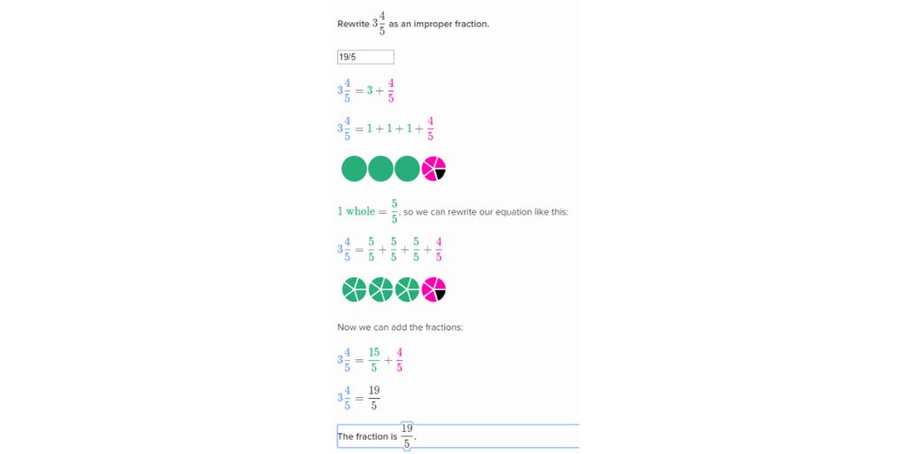

- **Why does this work?**
  - example 1: 5 1/4
    - The 5 is the same thing as 20/4
    - This make the fraction $20/4 + 1/4 = 21/4$
    - The 5 can be thought as 5 wholes, each split into four pieces. Count the pieces and you get 20 pieces.
  - example 2: 3 1/2
    - The 3 is the same thing as 6/2
    - This make the fraction $6/2 + 1/2 = 7/2$
    - The 3 can be fought of as 3 wholes, each split into 2 pieces. Count the pieces and you get 6 pieces.

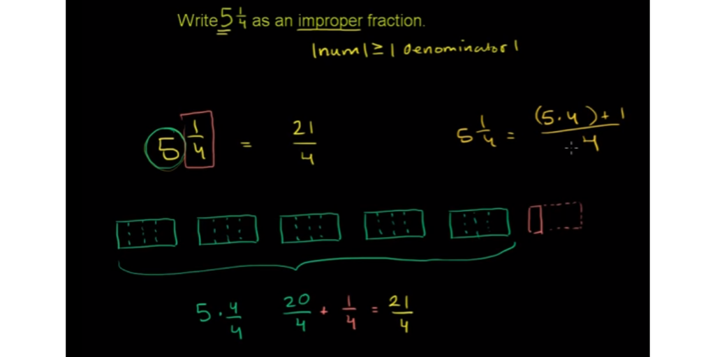

## Equivalent Fractions

- **equivalent fraction** = fractions with the same value / same part of the whole
- **On the number line** = fraction with the same location
- 2/4 = 1/2. Both share same amount of the whole (both have half the total slices), both appear at the same location on the number line (both appear half-way between the 0 and 1)
- **note**: No matter what you multiply or divide the fraction by, as long as the numerator and denominator are multiplied/divided by the same number then the fraction’s value will not change
  - 2/3 = 6/9 = 30/45
  - We multiplied the first fraction by 3, then the second fraction by 5, yet all equal the same value.

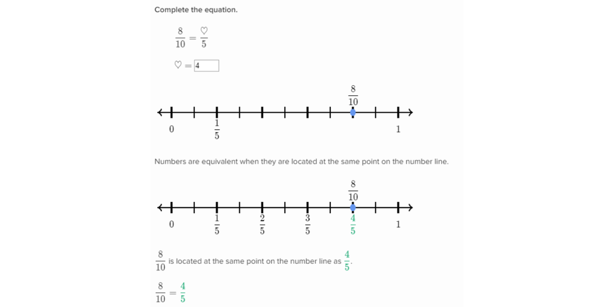

- **Equivalent Fraction Models**
- Complete the equation 8/12 = ?/3
  - Model A(1/12) has **four** pieces, for each piece of model B(1/3)
  - divide Model A’s numerator and denomator by four = 8/12 -> 2/3
  - 8/12 = 2/3
- Complete the equation. 9/12 = ?/8
  - Model A(1/12) has 1.5 pieces for each piece of model B(1/8)
    - 12/8 = 1.5
  - divide numerator and denom of model A by 1.5 = 6/8
  - 9/12 = 6/8

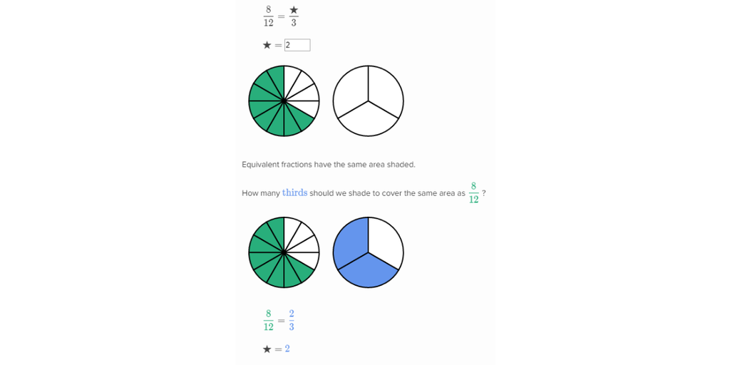

### Identifying equivalent fractions

- **Method One: Reduce both fractions into their simplest forms and see if they are the same**
  - **step one**: Reduce both fractions into their simplest form
    - Fraction A: Find number that divides both numerator and denominator
    - Fraction B: Find number that divides both numerator and denominator
  - **Step two**: Check if the reduced fractions are the same
    - If fraction A == fraction B, then fractions are equivalent
- **Method two: Intuitive workflow**
  - **step one**: Are the denominators the same?
    - Yes: Compare Numerators
    - No: Can you get the numerators/denominators the same?
      - i.e. 30/45 and 54/81. Divide the num/dom of 30/45 by 5 to get 6/9, and divide the nom/dom of 81 by 9 to get 6/9.
      - **note**: if you don’t multiply/divide the numerator/denominator by the same number the value of the fraction will change
      - yes: Do the fractions match?
      - no: probably not equivalent

### Create Equivalent Fractions

- **Method 1: Visually imagine both fractions as two equal cakes.**
- Cake A is sliced into *this many* slices and cake B is sliced into *this many* slices. If *this* many slices of cake A is eaten, how many slices of cake B needs to be eaten to equal the same amount of total cake?
  - $2/10 = p/100$ What number could replace P to create an equivalent fraction?
  - Fraction A represents dividing a rectangular cake into 10 slices and taking 2
  - Imagine we cut the cake into 100 slices instead, how many slices would equal the same amount of cake?
  - In order the take the same amount of cake, we need to take 20 out of the 100 slices
- **Method 2: Creating Equivalent Fractions by multiplying the numerator and denominator by th11e same number**
  - Another way is to multiply by $10/10$
  - $10/10 = 1/1$ so really we are multiplying by one
  - $2/10 = 20/100$
- **Method 3: 2/10 of 100 = 2/10 * 100/1 = 200/10 = 20**

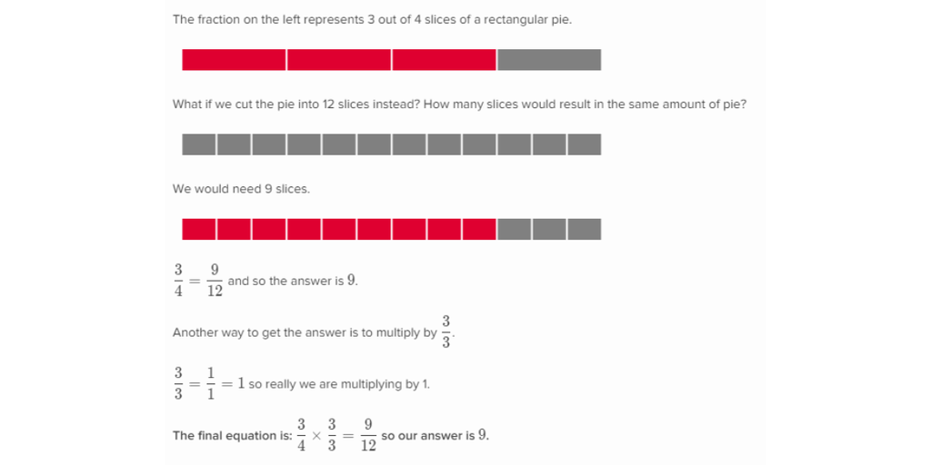

### Decomposing a mixed number

- **Numers ways of visually viewing a mixed number and decomposing it. Note, both fractions/models equal the same value**

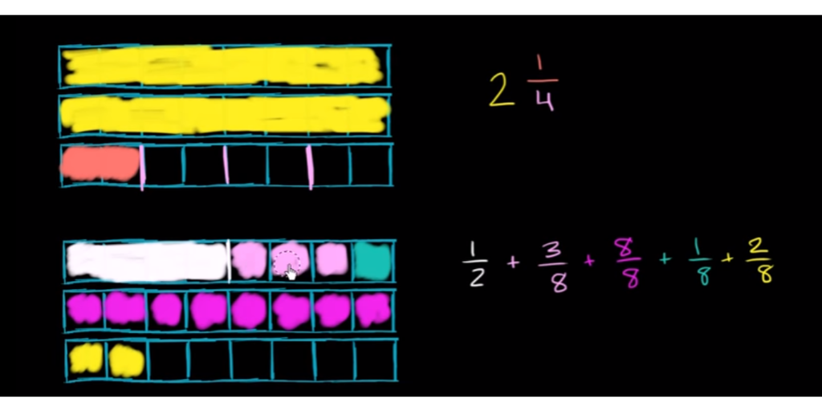

## Simplest form of a fraction

### Simplify fractions

- We simply fractions to make it easier to comprehend a value. When you simplify a fraction the value remains the same, even if we’re looking at smaller numbers! What’s easier to comprehend? 825.5/1651 or 1/2
- **use**: Easier to compare fractions (especially unlike fractions)
- Simplify 48/64
- To simplify fractions we can divide by a common factor, by **finding the greatest common factor** or **by dividing by common factors until the num/dom only have 1 for a common factor**
- **Method one**: Find GCF of numerator and denomator, divide each by GCD
  - **step one**: Find GCD
    - Break each number down into factors
      - 48 = 2 * 4 * 2 * 3
      - 64 = 2 * 4 * 2 * 4
    - Find largest set of common factors. 2 * 2 * 4 = 16
  - **step two**: divide num and dom by GCD to get simplest fraction
    - 48/64 divided by 16/16 = 3/4
  - **We are done simplifying when the only common factor of the numerator and denominator is 1
    - is there any number other than 1 that divides evntly into 3 and 4?
    - No, the only common factor of 3 and 4 is 1.
- **method two**: Divide the fraction by common factors
  - **step one**: Find GCD
    - Break each number down into factors into it becomes it’s simplest form
      - 48 / 2 = 24 / 4 = 6 / 2 = 3
      - 64/ 2 = 32 / 4 = 8 / 2 = 4
  - As long as you divide the num/dom until you only have 1 for a common factor, then you will get the answer in its simplest form

## Like Fractions

- Like fractions are fractions with the same denominator. We will see how to add like fraction together

### Adding up Like Fractions

- To add like fractions simply add the numerators together and keep the denominators the same
- **example**: 1/20 + 20/20 = 21/20. Which is saying a whole pie *plus* a slice equals a **whole pie and a slice**

## Comparing Fractions

- **In like fractions**, the fraction with the greatest numerator is largest
- **In fractions with the same numerator**, the fraction with the greatest denominator is smaller

### Comparing fractions with like numerators and denominators

- **In like fractions**, the fraction with the greatest numerator is largest
  - example: Which is largest? 4/7 or 5/7
    - re-write: $4/7 = 4 * 1/7$ and $5/7 = 5 * 1/7$
    - 4/7 has four 1/7th’s, whereas has 5/7 has five 1/7’ths. 5/7 is larger.
    - $4/7 < 5/7$
- **In fractions with the same numerator**, the fraction with the greatest denominator is smaller
  - example: Compare 3/4 and 3/9
    - re-write: $3/4 = 3 * 1/4$ and $3/9 = 3 * 1/9$
    - Which pieces are smaller? $1/4$ is a square split into four equal pieces, $1/9$ is a square split into nine equal pieces.
    - $1/4$ is split into fewer pieces, so a *fourth* is larger than a *ninth* OR $1/9$ has smaller pieces, so a *ninth* is smaller than a *fourth*
    - $3/4 > 3/9$

### Comparing fractions with unlike numerators and denominators

- To compare unlike fractions, change both fractions to share a common a denomiator (i.e. split all the pies into the same equal pieces)
  - step 1: Simplify Fraction (this makes finding the LCM and subsequent multiplying easier )
  - step 2: Find Lowest Common Multiple of both denominators, this will be the common denominator
    - Prime Factorize Each Denominator, then find the LCM using a superset that contains all prime factors
  - step 3: Make both fractions share a common denomiator by multiplying the denominator/numerator of each fraction (multiplying the numerator *and* denominator of a fraction by the *same* number does *not* change the value)
  - step 4: Now both fractions have the same denominator, **compare the numerator!**
- **example**: compare 1/12 and 4/8
  - step 1: Simplify Fraction (this makes finding the LCM and subsequent multiplying easier )
    - Already simplified
  - step 2: Find Lowest Common Multiple of both denominators, this will be the common denominator
    - Prime Factorize each and find the superset of primes
    - 2*2*2*3 = 24.
    - 24 is the lowest common multiple / shared denominator
  - step 3: Make both fractions share a common denomiator by multiplying the denominator/numerator of each fraction (multiplying the numerator *and* denominator of a fraction by the *same* number does *not* change the value)
    - $1/12 * 2/2 = 2/24$
    - $4/8 * 3/3 = 12/24$
  - step 4: Now both fractions have the same denominator, **compare the numerator!**
    - $2/24 < 12/24$
    - $1/12 < 4/8$
- **note**: You can often tell intuitively which fraction is smaller/larger by remembering that a **larger denominator** means that the square is sliced into **many** and thus **smaller** equal pieces, and a **smaller numerator** is opposite, meaning the square is split into **fewer** and thus **larger** equal pieces
- **note**: When changing an unlike fraction to a like fraction you are **not changing** the value of the fractions, but simply how they are **represented** so it’s easier to compare.

### Ordering Fractions

- The easiest way to order a bunch of fractions is to make all fractions **like fractions** (have the same denominator) and then compare the numerators (to compare exactly, all pies need to be sliced into the same amount of slices)
- To turn unlike fractions into unlike fractions, you need to find a common denominator, by **first** prime factorizing each fraction’s denominator, **then** finding the LCM of those denominators (as shown above(“comparing unlike…”) and below)
- **example**: Order $3/4, 3/6, 5/12$
  - Turn the unlike fractions into like fractions
  - step 1: Prime factorize the denominator of each fraction
  - step 2: Find the LCM, using the superset containing all prime factors
    - $2*2*2 = 12$
  - step 3: Change the fractions to have a common denominator by multiplying the num/denom by the same number
    - $3/4 * 3/3 = 9/12$
    - $3/6 * 2/2 = 6/12$
    - $5/12 = 5/12$
  - $3/4 > 3/6 > 5/12$
  - **note**: an intuitive way to look at it is that 3/4 is more than half the pie, 3/6 is half the pie and 5/12 is less than half the pie
- **note**: When changing an unlike fraction to a like fraction you are **not changing** the value of the fractions, but simply how they are **represented** so it’s easier to compare.

## Addition and Subtraction of fractions

### Addition of like fractions

- **Is fraction mixed?** No
- **Are the denominators the same?** Yes
- **Add up numerators, keep denominators the same and simplify!**
- $3/15 + 7/15 = 10/15 = 2/3$
  - simplify: if you changed **5** of the **15th pieces** into **one piece**, how many pieces would you have? 3.
  - i.e. if you merged every 5 of the 15 slices into one big slice, how many slices would the pie have? 3 big slices.

### Addition of unlike fractions

- **Change unlike fractions to like by finding a common denominator via finding the LCM**
  - LCM = a number that both denominators divide into
- Look at examples in “Comparing unlike fractions/Ordering fractions”
- **note**: When changing an unlike fraction to a like fraction you are **not changing** the value of the fractions, but simply how they are **represented** so it’s easier to compare.
  - i.e. if you have 2 identical pies, pie A is sliced into three slices and pie B is sliced into 2 slices. If you want know which pie has been eaten more, you make both pies have the same amount of slices, by slicing them into 6 pieces each.

### Addition of mixed numbers

- **Think of mixed numbers as a whole number AND a fraction. You can add whole numbers and you can add fractions with like denominators. Therefore, you can add mixed numbers!**
- Add mixed numbers together, simplify
- First, **add whole number part,** then **add fraction part**
- 17 2/9 + 5 1/9
  - Step 1: Expand out and re-write
  - 17 + 2/9 + 5 + 1/9
  - Step 2: Add whole numbers, then fractions (remember, the commumtative law of addition states order does not matter)
  - (17 + 5) + (2/9 + 1/9)
  - 22 + 3/9
  - Step 3: simplify
  - 22 1/3

### Adding mixed numbers with unlike denominators

- Add mixed numbers together, simplify
  - Add whole number part and then add fraction part
  - If fractions are unlike, turn them into **like fractions** by finding LCM/common denom
- **3 1/12 + 11 2/5 + 4 3/15**
  - Step 1: Expand out, breaking mixed number into whole number and fraction part
  - 3 + 1/12 + 11 + 2/5 + 4 + 3/15
  - Step 2: Add whole numbers, then fractions (remember, the commumtative law of addition states order does not matter)
  - (3 + 11 + 4) + (1/12 + 2/5 + 3/15)
  - 18 + (1/12 + 2/5 + 3/15)
  - Step 3: Can’t add fractions because they are unlike. Convert fractions to like by finding common denominator/LCM
  - 18 + (5/60 + 24/60 + 12/60)
  - **18 41/60**

### Adding mixed number with an improper fraction

- **improper fraction** = numerator larger then denominator
- there are 2 methods, **method one: converting to improper fractions** or **method two: adding whole number part, then fraction part**. We will use latter method
- Add whole number part and then fraction part, then convert improper fraction to proper
- 1 4/8 + 2 5/8
  - step 1: Expand out, breaking mixed number into whole number and fraction part (rewrite)
  - 1 + 4/8 + 2 + 5/8
  - step 2: add whole numbers and fractions
  - 3 + 9/8
  - step 3: re-write improper fraction
  - 3 + 1 1/8
  - 4 + 1/8
  - **4 1/8**

### Substracting mixed numbers

- there are 2 methods, **method one: converting to improper fractions** or **method two: adding whole number part, then fraction part**. We will use latter method
- 5 5/8 - 2 1/5
- Step one: subtract whole numbers part and subtract fractions part
  - 3 + (5/8 - 1/5)
- Step two: convert fractions into like fractions by finding common denominator (a number which divides by both 8 and 5, the lCM)
  - 3 + (25/40 - 8 /40)
- **3 17/40**
- **note**: if you are substracting a larger fraction from a smaller one, which will result in a negative fraction, it is better to do **method one**, where you go straight to an improper fraction for both of them

### Substracting mixed numbers with negatives

- When you are substracting a larger fraction from a smaller one, which will result in a negative fraction, it is better to do **method one**, where you go straight to an improper fraction for both of them
- there are 2 methods, **method one: converting to improper fractions** or **method two: adding whole number part, then fraction part**. **We will show both**
- 8 2/3 - 5 5/6
- **method one**: converting to improper fractions straight away
  - step one: convert to improper fraction
  - 26/3 - 35/6
  - step two: convert to like fraction (find common denominator, i.e. LCM)
  - 52/6 - 35/6
  - step three: substract and convert into mixed
  - 52/6 - 35/6 = 17/6 = **2 5/6**
  - **note**: improper fraction method will also work but sometimes it can be a little harder or easier, depending on fractions
- **method two**: adding whole number part, then fraction part
  - Step one: subtract whole numbers part and subtract fractions part
  - 8 2/3 - 5 5/6
  - (8-5) + (2/3 - 5/6)
  - 3 + (2/3 - 5/6)
  - Step two: convert fractions into like fractions by finding common denominator (the smallest number which divides by 3 and 6, the lCM)
  - 3 + (4/6 - 5/6)
  - we can’t subtract 4/6 - 5/6 because 5/6 is larger
  - step three: re-group fraction to make 4/6 larger than 5/6*
  - 2 + 1 + (4/6 - 5/6)
  - 2 + 6/6 + (4/6 - 5/6)
  - 2 + (10/6 - 5/6)
  - **2 + 5/6**
- **method three: similar to method two but grouping takes place before adding whole numbers. Potentially easier**
  - Step one: re-write mixed numbers with their fractional parts and whole number parts and re-write the fractions with a common denominator
  - 8 2/3 - 5 5/6
  - (8-5) + (2/3 - 5/6)
  - (8-5) + (4/6 - 5/6)
  - we can’t subtract 4/6 - 5/6 because 5/6 is larger
  - step two: re-group fraction to make 4/6 larger than 5/6*
  - 8 4/6 can be regrouped so that the fractional part is **greater** than 5/6
  - 8 4/6
  - 8 + 4/6
  - 7 + 1 + 4/6
  - 7 + 6/6 + 4/6
  - 7 + 10/6
  - (7-5) + (10/6 - 5/6)
  - **2 + 5/6**

# Chapter 8: Decimals

- Decimals are useful in the real world for weighing and measuring things. Why? Because not everything is an exact whole number. For example, you might have 1 and 1/2 packets of polo, or 1.5 packets of polos.
- Remember, decimals show numbers less than one.
  - For example, let’s say you measure a grain of sand with a ruler. It goes past 1 but doesn’t quite reach 2.
  - Do we just give up? or take the number which is closest? No! Let’s split up the distance between 1 and 2 into tenths.
  - Ok, so we can see it’s between 1.2 and 1.3, but it isn’t hitting eithr of them exactly.
  - So, now do we give up? Nooooo!! Let’s split again, this time splitting the space between 1.2 and 1.3 into hundreths!
  - Hey, it’s hit a point! The grain of sand is 1.25 long! Wo-hooooo.
  - **The key thing to remember is fractions is about splitting stuff up into smaller pieces to make it more precise when we measure. What will give you more precision when you sew? A thick clunky needle made of bone or a thin steel needle with a tiny sharp point? We get more precision and accuracy with smaller things and some things are too small to be measured by big numbers, just like bugs which are too small to be seen without a microscope!**

## Introduction to decimals

- **decimals** are like fractions, they are a way of showing numbers less than one.
- Everything beyond the decimal point is a fraction, a number less than one, and everything to the left of the decimal is a whole number

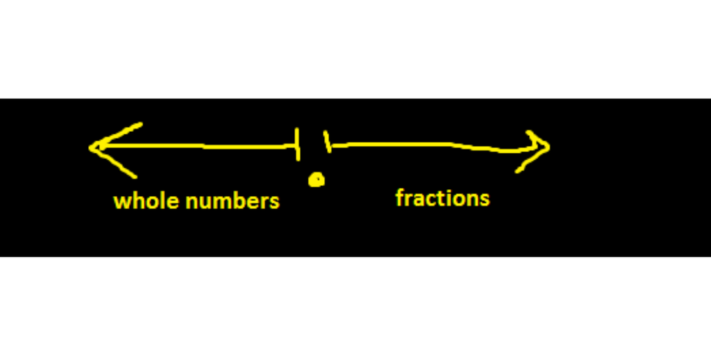

## Writing Decimals in different forms

- **example**: 151.4
- Decimal Form: 151.4
- Fractional form: 1/100s + 5/10s + 1/1s + 4/ 1/10
  - 100s = 10^2, 10s = 10^1, 1s = 10^0, 1/10’s = 10^-1,
  - 1 hundred**S**, 5 ten**S**, 1 one**S**, 4 ten**THS**
- Expanded form: 100 + 50 + 1 + 4/10
- expanded form v2: (1 * 100) + (5 * 10) + (1 * 1) + (4 * 1/10)
- mixed number: 151 4/10
- word form: one hundred and fifty one and 4 tenths
- **example**: 0.76
- Decimal Form: 0.76
- Fractional form: 0/1s + 7/ (1/10s) + 6 / (1/100s)
  - 1s = 10^0, 1/10’s = 10^-1, 1/100’s = 10^-2
  - 0 one**S**, 7 ten**THS**, 6 hundre**THS**
- Expanded form: 0 + 7/10 + 6/100
  - 0 + 70/100 + 6/100
  - 76/100 = 0.76
- expanded form v2: 7 * 1/10 + 6 * 1/100
  - don’t have to write columns with zero, such as the ones column
- mixed number: 0 + 76/100
- word form: 76 hundreths
  - 7 tenths (7/10) and 6 hundreths (6/100) = 76 hundreths (76/100)

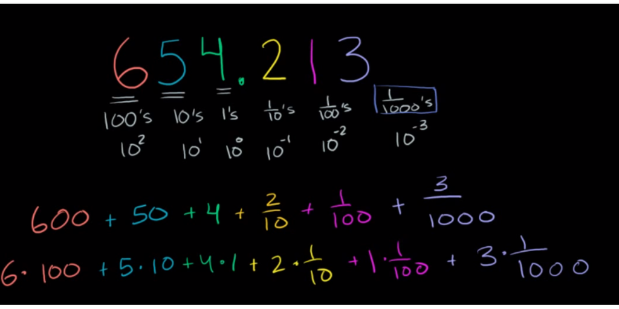

## Tenths and Hundreds

### writing decimals shown in grids

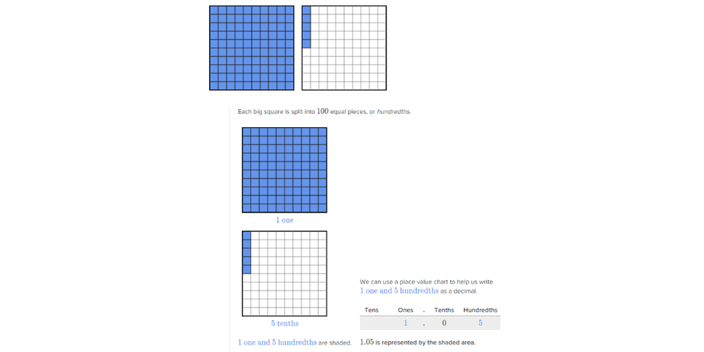

### Comparing decimal place value

- Multiplying by a fraction moves each digit to the right
  - multiplying by 1/10 moves each digit one value place to the right
  - multiplying by 1/100 moves each digit 2 value places to the right
- Multiplying by a positive whole number moves each digit number to the left
  - multipling by 10 moves each digit one value place to the left
- **example**: 83 hundreths x 1/10 = 83 thousandths
  - multiplying by 1/10 moves each digit one value place to the right
  - if we have 83 hundreths and we multiply them by 1/10, then each of the hundreths become a thousandths
  - now instead of 83 hundreths we have 83 thousandths

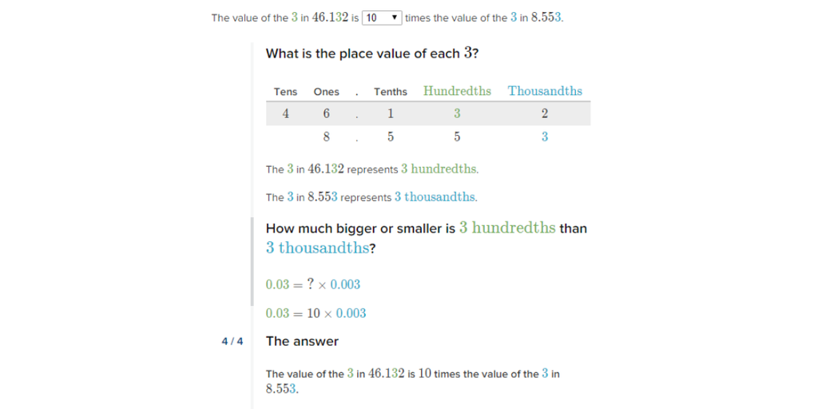

### Decimals on the number lines

- **tens**
  - First, check the distance between 2 whole numbers and state by how many equal pieces it is divided by
  - Next, state what each tick represents, i.e. 0.1 or 1 tenth
  - In the example below the answer represents 6 ones and 2 tenths, or 62 tenths
  - 1.9 is one-tenth less than 2.0. Understand now?

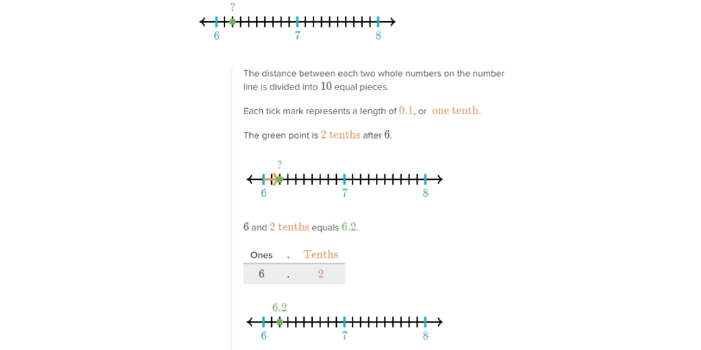

- **hundreds**
  - The distance between two numbers is 1 tenth or 0.1
  - This tenth is divided into 10 equal pieces. 0.1/10 = 0.01
  - Each tick marks 0.01 or a hundreth

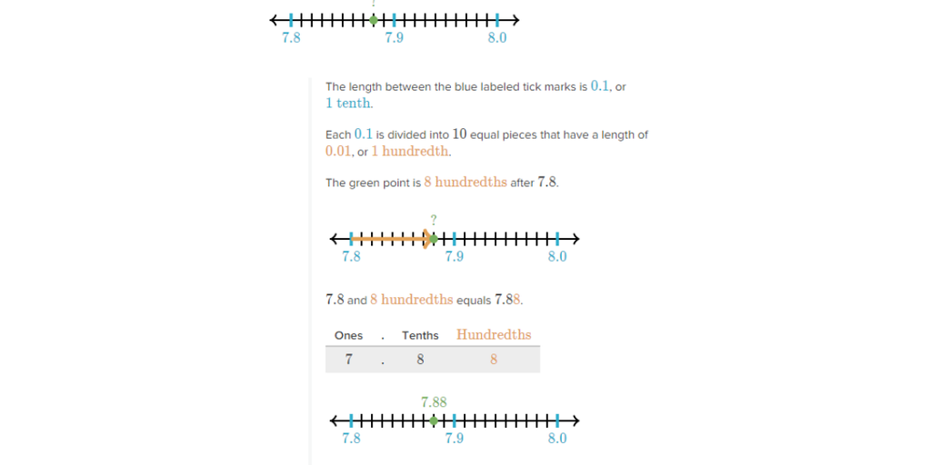

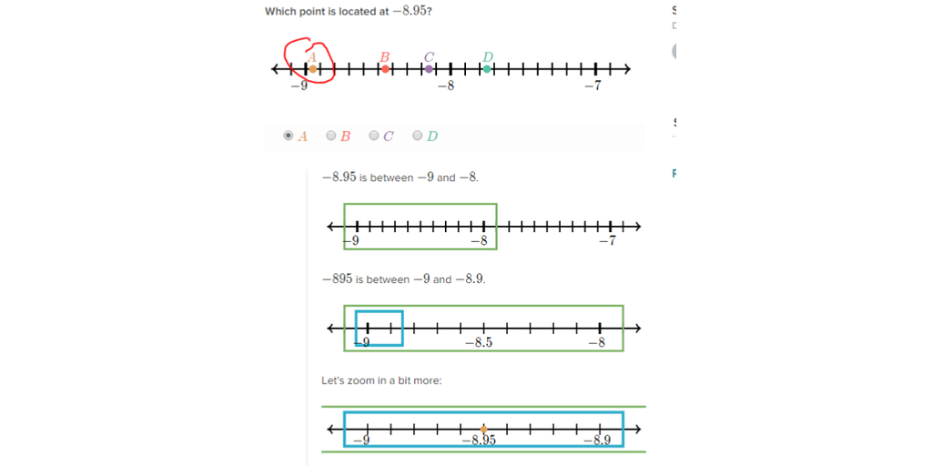